# 重賞レース予測レポート【レース終了】

作成日時: 2025/11/09 17:00:17

☞ [マニュアル(pdf)](https://ryutoro-galois.github.io/keiba-predictor/manual/manual.pdf)

☞ 過去5年の同一レース結果: [2024年](https://ryutoro-galois.github.io/keiba-predictor/report/PredResult_2024y_raceDate_20241102_20241103.html), [2023年](https://ryutoro-galois.github.io/keiba-predictor/report/PredResult_2023y_raceDate_20231104_20231105.html), [2022年](https://ryutoro-galois.github.io/keiba-predictor/report/PredResult_2022y_raceDate_20221105_20221106.html), [2021年](https://ryutoro-galois.github.io/keiba-predictor/report/PredResult_2021y_raceDate_20211106_20211107.html), [2020年](https://ryutoro-galois.github.io/keiba-predictor/report/PredResult_2020y_raceDate_20201107_20201108.html)

☞ 過去4週間の別レース結果: [1週前(11/1-2)](https://ryutoro-galois.github.io/keiba-predictor/report/PredResult_2025y_raceDate_20251101_20251102.html), [2週前(10/25-26)](https://ryutoro-galois.github.io/keiba-predictor/report/PredResult_2025y_raceDate_20251025_20251026.html), [3週前(10/18-19)](https://ryutoro-galois.github.io/keiba-predictor/report/PredResult_2025y_raceDate_20251018_20251019.html), [4週前(10/11-13)](https://ryutoro-galois.github.io/keiba-predictor/report/PredResult_2025y_raceDate_20251011_20251013.html)

☞ netkeiba: [京王杯2歳ステークス(GⅡ)](https://race.netkeiba.com/race/result.html?race_id=202505050111&rf=race_submenu), [京都ジャンプステークス(JGⅢ)](https://race.netkeiba.com/race/result.html?race_id=202508040108&rf=race_submenu), [アルゼンチン共和国杯(GⅡ)](https://race.netkeiba.com/race/result.html?race_id=202505050211&rf=race_submenu), [みやこステークス(GⅢ)](https://race.netkeiba.com/race/result.html?race_id=202508040211&rf=race_submenu)

☞ レース結果(csv): [11/8-9](https://ryutoro-galois.github.io/keiba-predictor/csv/race_result_20251108_20251109.csv)

## 【レース結果(1)】人気と着順の関係

### 【京王杯2歳ステークス(2025/11/08(土))】

【京王杯2歳ステークス(GⅡ)】  
2025/11/08(土), 05_東京, 芝左1400m

[interactive chart not shown]

### 【京都ジャンプステークス(2025/11/08(土))】

【京都ジャンプステークス(J.GⅢ)】  
2025/11/08(土), 08_京都, 障芝内-外3170m

[interactive chart not shown]

### 【アルゼンチン共和国杯(2025/11/09(日))】

【アルゼンチン共和国杯(GⅡ)】  
2025/11/09(日), 05_東京, 芝左2500m

[interactive chart not shown]

### 【みやこステークス(2025/11/09(日))】

【みやこステークス(GⅢ)】  
2025/11/09(日), 08_京都, ダ右1800m

[interactive chart not shown]

## 【レース結果(2)】コーナー通過順位

### 【京王杯2歳ステークス(2025/11/08(土))】

【京王杯2歳ステークス(GⅡ)】  
2025/11/08(土), 05_東京, 芝左1400m

[interactive chart not shown]

### 【京都ジャンプステークス(2025/11/08(土))】

【京都ジャンプステークス(J.GⅢ)】  
2025/11/08(土), 08_京都, 障芝内-外3170m

[interactive chart not shown]

### 【アルゼンチン共和国杯(2025/11/09(日))】

【アルゼンチン共和国杯(GⅡ)】  
2025/11/09(日), 05_東京, 芝左2500m

[interactive chart not shown]

### 【みやこステークス(2025/11/09(日))】

【みやこステークス(GⅢ)】  
2025/11/09(日), 08_京都, ダ右1800m

[interactive chart not shown]

## 0. 推し馬予測 (AI予測)

### 【京王杯2歳ステークス(GⅡ) 2025/11/08(土)】

- 本命(◎): 1-3着内確率(勝負強さ)が1位の馬
- 対抗(◯): 1-3着内確率が2-N位(20%程度以上)の中で予測タイムが最も速い馬
- 3番手(▲): 1-3着内確率が2-N位(20%程度以上)のでダークホース確率が最も高い馬
- 穴: ダークホース確率が上位1-M位(40%程度以上)の中で1-3着内確率が最も高い馬

| 推し馬 | 枠番 | 馬番 | 人気 | オッズ | 馬名 | 騎手 | 調教師 | 予測タイム(sec) | 1_順位 | 1-3着内確率(%) | 2_順位 | ﾀﾞｰｸﾎｰｽ確率(%) | 3_順位 |
| --- | --- | --- | --- | --- | --- | --- | --- | --- | --- | --- | --- | --- | --- |
| 本命(◎) | 3 | 6 | 2 | 7.6 | シュペルリング | 津村明秀 | 嘉藤貴行 | 86.8 | 6 | 40.8 | 1 | 0.7 | 14 |
| 対抗(◯) | 8 | 16 | 3 | 8.2 | レッドスティンガー | 横山和生 | 矢嶋大樹 | 86.8 | 8 | 34.8 | 2 | 0.7 | 16 |
| 3番手(▲) | 1 | 2 | 6 | 14.6 | シャオママル | Ａ．プーシャン | 加藤士津八 | 86.9 | 12 | 22.6 | 5 | 1.5 | 10 |
| 穴 | 3 | 5 | 9 | 31.4 | シーミハットク | 三浦皇成 | 寺島良 | 85.6 | 2 | 11.9 | 9 | 49.9 | 6 |

### 【京都ジャンプステークス(J.GⅢ) 2025/11/08(土)】

- 本命(◎): 1-3着内確率(勝負強さ)が1位の馬
- 対抗(◯): 1-3着内確率が2-N位(20%程度以上)の中で予測タイムが最も速い馬
- 3番手(▲): 1-3着内確率が2-N位(20%程度以上)のでダークホース確率が最も高い馬
- 穴: ダークホース確率が上位1-M位(40%程度以上)の中で1-3着内確率が最も高い馬

| 推し馬 | 枠番 | 馬番 | 人気 | オッズ | 馬名 | 騎手 | 調教師 | 予測タイム(sec) | 1_順位 | 1-3着内確率(%) | 2_順位 | ﾀﾞｰｸﾎｰｽ確率(%) | 3_順位 |
| --- | --- | --- | --- | --- | --- | --- | --- | --- | --- | --- | --- | --- | --- |
| 本命(◎) | 7 | 7 | 3 | 7.7 | ナリノモンターニュ | 五十嵐雄祐 | 上原博之 | 220.4 | 3.0 | 24.9 | 1 | 1.1 | 8 |
| 対抗(◯) | 8 | 9 | 1 | 1.7 | ディナースタ | 高田潤 | 辻野泰之 | 210.7 | 1.0 | 20.2 | 3 | 0.7 | 9 |
| 3番手(▲) | 2 | 2 | 2 | 3.8 | レッドバロッサ | 小牧加矢太 | 佐藤悠太 | 212.4 | 2.0 | 23.6 | 2 | 0.6 | 10 |
| 穴 | 3 | 3 | 6 | 17.8 | ローディアマント | 伴啓太 | 尾関知人 | 228.2 | 7.5 | 11.3 | 6 | 41.3 | 2 |

### 【アルゼンチン共和国杯(GⅡ) 2025/11/09(日)】

- 本命(◎): 1-3着内確率(勝負強さ)が1位の馬
- 対抗(◯): 1-3着内確率が2-N位(20%程度以上)の中で予測タイムが最も速い馬
- 3番手(▲): 1-3着内確率が2-N位(20%程度以上)のでダークホース確率が最も高い馬
- 穴: ダークホース確率が上位1-M位(40%程度以上)の中で1-3着内確率が最も高い馬

| 推し馬 | 枠番 | 馬番 | 人気 | オッズ | 馬名 | 騎手 | 調教師 | 予測タイム(sec) | 1_順位 | 1-3着内確率(%) | 2_順位 | ﾀﾞｰｸﾎｰｽ確率(%) | 3_順位 |
| --- | --- | --- | --- | --- | --- | --- | --- | --- | --- | --- | --- | --- | --- |
| 本命(◎) | 2 | 3 | 7 | 15.9 | ローシャムパーク | Ａ．プーシャン | 田中博康 | 149.9 | 2 | 28.9 | 1 | 2.3 | 10 |
| 対抗(◯) | 3 | 5 | 9 | 27.2 | セレシオン | 荻野極 | 友道康夫 | 149.9 | 2 | 21.8 | 2 | 1.6 | 13 |
| 3番手(▲) | 3 | 6 | 3 | 5.9 | ディマイザキッド | 岩田望来 | 清水英克 | 161.1 | 14 | 20.3 | 3 | 0.6 | 16 |
| 穴 | 2 | 4 | 17 | 122.7 | サスツルギ | 北村宏司 | 千葉直人 | 160.6 | 12 | 10.7 | 9 | 55.4 | 1 |

### 【みやこステークス(GⅢ) 2025/11/09(日)】

- 本命(◎): 1-3着内確率(勝負強さ)が1位の馬
- 対抗(◯): 1-3着内確率が2-N位(20%程度以上)の中で予測タイムが最も速い馬
- 3番手(▲): 1-3着内確率が2-N位(20%程度以上)のでダークホース確率が最も高い馬
- 穴: ダークホース確率が上位1-M位(40%程度以上)の中で1-3着内確率が最も高い馬

| 推し馬 | 枠番 | 馬番 | 人気 | オッズ | 馬名 | 騎手 | 調教師 | 予測タイム(sec) | 1_順位 | 1-3着内確率(%) | 2_順位 | ﾀﾞｰｸﾎｰｽ確率(%) | 3_順位 |
| --- | --- | --- | --- | --- | --- | --- | --- | --- | --- | --- | --- | --- | --- |
| 本命(◎) | 7 | 12 | 2 | 6.4 | ダブルハートボンド | 坂井瑠星 | 大久保龍志 | 112.1 | 6.0 | 41.8 | 1 | 0.7 | 14 |
| 対抗(◯) | 4 | 6 | 4 | 7.3 | ロードクロンヌ | 横山和生 | 四位洋文 | 112.1 | 5.0 | 30.6 | 2 | 1.1 | 11 |
| 3番手(▲) | 4 | 7 | 5 | 9.1 | シゲルショウグン | 幸英明 | 大橋勇樹 | 112.2 | 7.0 | 27.1 | 3 | 1.4 | 8 |
| 穴 | 8 | 15 | 14 | 47.5 | デルマソトガケ | 団野大成 | 須貝尚介 | 112.0 | 3.5 | 8.3 | 9 | 45.4 | 1 |

## 1. 予測チャート (タイム/勝負強さ)

### 【京王杯2歳ステークス(GⅡ)】

2025/11/08(土), 05_東京, 芝左1400m

[interactive chart not shown]

### 【京都ジャンプステークス(J.GⅢ)】

2025/11/08(土), 08_京都, 障芝内-外3170m

[interactive chart not shown]

### 【アルゼンチン共和国杯(GⅡ)】

2025/11/09(日), 05_東京, 芝左2500m

[interactive chart not shown]

### 【みやこステークス(GⅢ)】

2025/11/09(日), 08_京都, ダ右1800m

[interactive chart not shown]

## 2. オッズモニタリング (毎時)

### 【京王杯2歳ステークス】

[interactive chart not shown]

### 【京都ジャンプステークス】

[interactive chart not shown]

### 【アルゼンチン共和国杯】

[interactive chart not shown]

### 【みやこステークス】

[interactive chart not shown]

## 3. 出馬表

### 【京王杯2歳ステークス 2025/11/08(土) 】

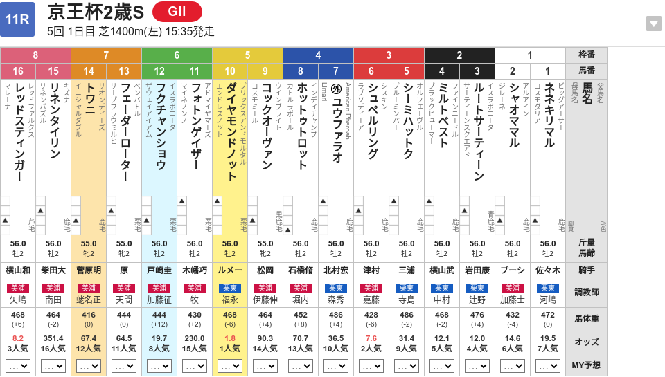

### 【京都ジャンプステークス 2025/11/08(土) 】

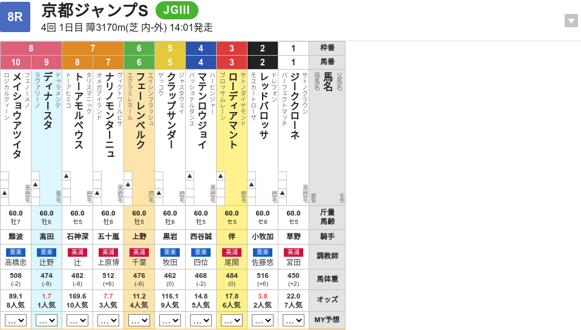

### 【アルゼンチン共和国杯 2025/11/09(日) 】

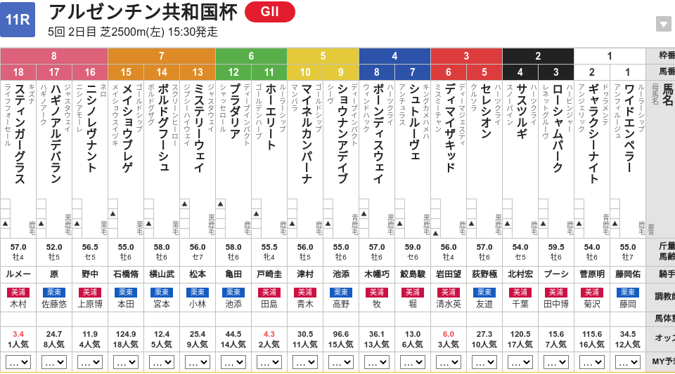

### 【みやこステークス 2025/11/09(日) 】

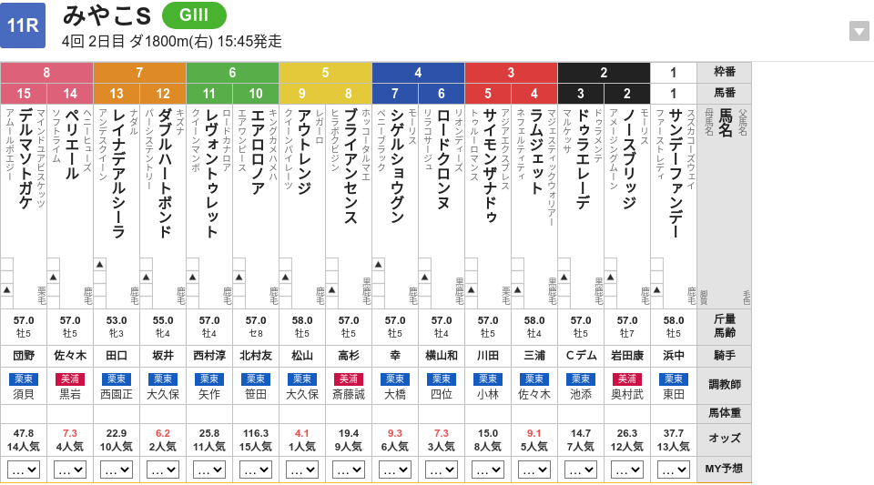

## 4. 単勝予測結果

### 【京王杯2歳ステークス(GⅡ) 2025/11/08(土)】

| 枠番 | 馬番 | 人気 | オッズ | 馬名 | 騎手 | 調教師 | 予測タイム(sec) | 1_順位 | 1-3着内確率(%) | 2_順位 | ﾀﾞｰｸﾎｰｽ確率(%) | 3_順位 |
| --- | --- | --- | --- | --- | --- | --- | --- | --- | --- | --- | --- | --- |
| 1 | 1 | 7 | 19.5 | ネネキリマル | 佐々木大輔 | 河嶋宏樹 | 87.0 | 13.0 | 19.3 | 6 | 1.5 | 9.0 |
| 1 | 2 | 6 | 14.6 | シャオママル | Ａ．プーシャン | 加藤士津八 | 86.9 | 12.0 | 22.6 | 5 | 1.5 | 10.0 |
| 2 | 3 | 4 | 12.0 | ルートサーティーン | 岩田康誠 | 辻野泰之 | 87.0 | 14.5 | 24.7 | 3 | 1.2 | 13.0 |
| 2 | 4 | 5 | 12.1 | ミルトベスト | 横山武史 | 中村直也 | 87.0 | 14.5 | 24.4 | 4 | 1.2 | 12.0 |
| 3 | 5 | 9 | 31.4 | シーミハットク | 三浦皇成 | 寺島良 | 85.6 | 2.0 | 11.9 | 9 | 49.9 | 6.0 |
| 3 | 6 | 2 | 7.6 | シュペルリング | 津村明秀 | 嘉藤貴行 | 86.8 | 6.0 | 40.8 | 1 | 0.7 | 14.0 |
| 4 | 7 | 10 | 36.5 | ユウファラオ | 北村宏司 | 森秀行 | 86.8 | 7.0 | 11.5 | 10 | 49.4 | 7.0 |
| 4 | 8 | 13 | 70.7 | ホットゥトロット | 石橋脩 | 堀内岳志 | 86.6 | 5.0 | 11.1 | 12 | 54.8 | 4.0 |
| 5 | 9 | 14 | 90.3 | コックオーヴァン | 松岡正海 | 伊藤伸一 | 86.8 | 10.0 | 8.5 | 14 | 58.6 | 1.0 |
| 5 | 10 | 1 | 1.8 | ダイヤモンドノット | Ｃ．ルメール | 福永祐一 | 81.2 | 1.0 | 17.8 | 7 | 0.7 | 15.0 |

[output cut: 6 more lines]

### 【京都ジャンプステークス(J.GⅢ) 2025/11/08(土)】

| 枠番 | 馬番 | 人気 | オッズ | 馬名 | 騎手 | 調教師 | 予測タイム(sec) | 1_順位 | 1-3着内確率(%) | 2_順位 | ﾀﾞｰｸﾎｰｽ確率(%) | 3_順位 |
| --- | --- | --- | --- | --- | --- | --- | --- | --- | --- | --- | --- | --- |
| 1 | 1 | 7 | 22.0 | ジーククローネ | 草野太郎 | 宮田敬介 | 228.2 | 7.5 | 10.1 | 7 | 40.9 | 3 |
| 2 | 2 | 2 | 3.8 | レッドバロッサ | 小牧加矢太 | 佐藤悠太 | 212.4 | 2.0 | 23.6 | 2 | 0.6 | 10 |
| 3 | 3 | 6 | 17.8 | ローディアマント | 伴啓太 | 尾関知人 | 228.2 | 7.5 | 11.3 | 6 | 41.3 | 2 |
| 4 | 4 | 5 | 14.8 | マテンロウジョイ | 西谷誠 | 四位洋文 | 227.8 | 6.0 | 12.5 | 5 | 1.5 | 6 |
| 5 | 5 | 9 | 116.1 | クラップサンダー | 黒岩悠 | 牧田和弥 | 229.6 | 9.0 | 2.0 | 10 | 12.5 | 4 |
| 6 | 6 | 4 | 11.2 | フェーレンベルク | 上野翔 | 千葉直人 | 227.7 | 5.0 | 16.3 | 4 | 1.5 | 7 |
| 7 | 7 | 3 | 7.7 | ナリノモンターニュ | 五十嵐雄祐 | 上原博之 | 220.4 | 3.0 | 24.9 | 1 | 1.1 | 8 |
| 7 | 8 | 10 | 169.6 | トーアモルペウス | 石神深一 | 辻哲英 | 227.2 | 4.0 | 9.1 | 8 | 57.1 | 1 |
| 8 | 9 | 1 | 1.7 | ディナースタ | 高田潤 | 辻野泰之 | 210.7 | 1.0 | 20.2 | 3 | 0.7 | 9 |
| 8 | 10 | 8 | 89.1 | メイショウアツイタ | 難波剛健 | 高橋義忠 | 229.8 | 10.0 | 2.0 | 9 | 10.7 | 5 |

### 【アルゼンチン共和国杯(GⅡ) 2025/11/09(日)】

| 枠番 | 馬番 | 人気 | オッズ | 馬名 | 騎手 | 調教師 | 予測タイム(sec) | 1_順位 | 1-3着内確率(%) | 2_順位 | ﾀﾞｰｸﾎｰｽ確率(%) | 3_順位 |
| --- | --- | --- | --- | --- | --- | --- | --- | --- | --- | --- | --- | --- |
| 1 | 1 | 12 | 35.0 | ワイドエンペラー | 藤岡佑介 | 藤岡健一 | 161.0 | 13.0 | 6.8 | 14 | 9.3 | 6 |
| 1 | 2 | 16 | 119.5 | ギャラクシーナイト | 菅原明良 | 菊沢隆徳 | 163.0 | 16.0 | 4.4 | 15 | 6.9 | 9 |
| 2 | 3 | 7 | 15.9 | ローシャムパーク | Ａ．プーシャン | 田中博康 | 149.9 | 2.0 | 28.9 | 1 | 2.3 | 10 |
| 2 | 4 | 17 | 122.7 | サスツルギ | 北村宏司 | 千葉直人 | 160.6 | 12.0 | 10.7 | 9 | 55.4 | 1 |
| 3 | 5 | 9 | 27.2 | セレシオン | 荻野極 | 友道康夫 | 149.9 | 2.0 | 21.8 | 2 | 1.6 | 13 |
| 3 | 6 | 3 | 5.9 | ディマイザキッド | 岩田望来 | 清水英克 | 161.1 | 14.0 | 20.3 | 3 | 0.6 | 16 |
| 4 | 7 | 6 | 12.9 | シュトルーヴェ | 鮫島克駿 | 堀宣行 | 160.2 | 9.0 | 9.1 | 11 | 1.2 | 14 |
| 4 | 8 | 13 | 36.3 | ボーンディスウェイ | 木幡巧也 | 牧光二 | 156.0 | 6.0 | 7.3 | 13 | 10.9 | 5 |
| 5 | 9 | 15 | 97.5 | ショウナンアデイブ | 池添謙一 | 高野友和 | 155.1 | 5.0 | 7.7 | 12 | 44.4 | 2 |
| 5 | 10 | 11 | 30.7 | マイネルカンパーナ | 津村明秀 | 青木孝文 | 160.4 | 10.5 | 9.7 | 10 | 32.7 | 3 |

[output cut: 8 more lines]

### 【みやこステークス(GⅢ) 2025/11/09(日)】

| 枠番 | 馬番 | 人気 | オッズ | 馬名 | 騎手 | 調教師 | 予測タイム(sec) | 1_順位 | 1-3着内確率(%) | 2_順位 | ﾀﾞｰｸﾎｰｽ確率(%) | 3_順位 |
| --- | --- | --- | --- | --- | --- | --- | --- | --- | --- | --- | --- | --- |
| 1 | 1 | 13 | 37.8 | サンデーファンデー | 浜中俊 | 東田明士 | 116.2 | 12.0 | 3.9 | 14 | 12.1 | 7 |
| 2 | 2 | 12 | 26.1 | ノースブリッジ | 岩田康誠 | 奥村武 | 120.5 | 15.0 | 7.1 | 12 | 12.7 | 6 |
| 2 | 3 | 7 | 14.7 | ドゥラエレーデ | Ｃ．デムーロ | 池添学 | 120.3 | 14.0 | 8.5 | 7 | 1.2 | 9 |
| 3 | 4 | 6 | 9.6 | ラムジェット | 三浦皇成 | 佐々木晶三 | 115.6 | 9.0 | 15.0 | 5 | 0.8 | 12 |
| 3 | 5 | 8 | 14.9 | サイモンザナドゥ | 川田将雅 | 小林真也 | 116.5 | 13.0 | 4.9 | 13 | 0.8 | 13 |
| 4 | 6 | 4 | 7.3 | ロードクロンヌ | 横山和生 | 四位洋文 | 112.1 | 5.0 | 30.6 | 2 | 1.1 | 11 |
| 4 | 7 | 5 | 9.1 | シゲルショウグン | 幸英明 | 大橋勇樹 | 112.2 | 7.0 | 27.1 | 3 | 1.4 | 8 |
| 5 | 8 | 9 | 19.0 | ブライアンセンス | 高杉吏麒 | 斎藤誠 | 116.1 | 11.0 | 8.3 | 8 | 30.8 | 4 |
| 5 | 9 | 1 | 4.0 | アウトレンジ | 松山弘平 | 大久保龍志 | 107.8 | 1.0 | 7.7 | 11 | 0.4 | 15 |
| 6 | 10 | 15 | 117.7 | エアロロノア | 北村友一 | 笹田和秀 | 116.0 | 10.0 | 3.5 | 15 | 22.0 | 5 |

[output cut: 5 more lines]

## 5. 人気と着順の乖離率推移

### 【京王杯2歳ステークス_2001y_2019y】

[interactive chart not shown]

### 【京都ジャンプステークス_1999y_2019y】

[interactive chart not shown]

### 【アルゼンチン共和国杯_1990y_2019y】

[interactive chart not shown]

### 【みやこステークス_2010y_2019y】

[interactive chart not shown]

### 【京王杯2歳ステークス_2001y_2019y】

| No | 開催年 | 不整合率(%) | 頭数 | 人気別着順(1-3位) | 人気別着順(全体) |
| --- | --- | --- | --- | --- | --- |
| 19 | 2019 | 30.4 | 10頭 | 1-3-4 | 1\|3\|4\|6\|5\|8\|7\|9\|2\|10 |
| 18 | 2018 | 29.4 | 8頭 | 2-1-6 | 2\|1\|6\|5\|3\|7\|4\|8 |
| 17 | 2017 | 44.7 | 11頭 | 1-5-4 | 1\|5\|4\|7\|8\|6\|3\|2\|9\|10\|11 |
| 16 | 2016 | 38.8 | 13頭 | 3-1-4 | 3\|1\|4\|2\|9\|8\|7\|11\|12\|10\|5\|13\|6 |
| 15 | 2015 | 40.2 | 18頭 | 2-6-1 | 2\|6\|1\|7\|5\|13\|14\|12\|10\|11\|8\|4\|9\|3\|15\|18\|17\|16 |
| 14 | 2014 | 42.7 | 12頭 | 11-4-1 | 11\|4\|1\|6\|8\|3\|2\|12\|7\|9\|5\|10 |
| 13 | 2013 | 38.3 | 14頭 | 5-6-2 | 5\|6\|2\|9\|8\|1\|3\|4\|13\|10\|11\|7\|14\|12 |
| 12 | 2012 | 54.3 | 16頭 | 5-7-8 | 5\|7\|8\|12\|4\|11\|14\|2\|1\|13\|9\|3\|10\|15\|16\|6 |
| 11 | 2011 | 49.8 | 14頭 | 5-9-4 | 5\|9\|4\|1\|10\|7\|3\|2\|6\|11\|8\|13\|14\|12 |
| 10 | 2010 | 45.8 | 15頭 | 7-2-13 | 7\|2\|13\|4\|8\|5\|6\|11\|9\|1\|12\|3\|10\|15\|14 |

[output cut: 9 more lines]

### 【京都ジャンプステークス_1999y_2019y】

| No | 開催年 | 不整合率(%) | 頭数 | 人気別着順(1-3位) | 人気別着順(全体) |
| --- | --- | --- | --- | --- | --- |
| 21 | 2019 | 24.7 | 13頭 | 1-5-3 | 1\|5\|3\|2\|6\|4\|10\|7\|8\|11\|13\|9\|12 |
| 20 | 2018 | 37.9 | 9頭 | 2-3-1 | 2\|3\|1\|6\|5\|4\|8\|9\|7 |
| 19 | 2017 | 26.8 | 10頭 | 4-1-2 | 4\|1\|2\|6\|7\|11\|9\|10\|3\|8 |
| 18 | 2016 | 30.7 | 6頭 | 4-1-5 | 4\|1\|5\|2\|6\|3 |
| 17 | 2015 | 70.1 | 9頭 | 3-6-2 | 3\|6\|2\|7\|5\|4\|11\|8\|1 |
| 16 | 2014 | 25.6 | 13頭 | 2-1-6 | 2\|1\|6\|10\|4\|5\|11\|9\|12\|8\|13\|14\|7 |
| 15 | 2013 | 32.6 | 7頭 | 1-4-3 | 1\|4\|3\|2\|5\|7\|6 |
| 14 | 2012 | 84.1 | 7頭 | 6-4-5 | 6\|4\|5\|7\|3\|2\|8 |
| 13 | 2011 | 57.0 | 11頭 | 3-5-6 | 3\|5\|6\|10\|2\|1\|4\|7\|8\|9\|11 |
| 12 | 2010 | 27.4 | 12頭 | 4-1-7 | 4\|1\|7\|2\|5\|8\|3\|9\|6\|10\|11\|12 |

[output cut: 11 more lines]

### 【アルゼンチン共和国杯_1990y_2019y】

| No | 開催年 | 不整合率(%) | 頭数 | 人気別着順(1-3位) | 人気別着順(全体) |
| --- | --- | --- | --- | --- | --- |
| 30 | 2019 | 30.0 | 13頭 | 2-5-1 | 2\|5\|1\|3\|9\|11\|10\|6\|8\|12\|4\|7\|13 |
| 29 | 2018 | 40.8 | 12頭 | 3-1-11 | 3\|1\|11\|4\|8\|6\|10\|2\|5\|7\|9\|12 |
| 28 | 2017 | 24.9 | 16頭 | 1-7-3 | 1\|7\|3\|2\|8\|15\|12\|4\|6\|9\|11\|13\|16\|14\|5\|10 |
| 27 | 2016 | 36.2 | 15頭 | 2-4-3 | 2\|4\|3\|1\|5\|8\|6\|7\|13\|11\|10\|9\|12\|14\|15 |
| 26 | 2015 | 31.5 | 18頭 | 1-4-3 | 1\|4\|3\|7\|8\|10\|2\|12\|11\|5\|15\|9\|14\|17\|18\|16\|13\|6 |
| 25 | 2014 | 46.5 | 18頭 | 2-4-3 | 2\|4\|3\|9\|6\|11\|8\|14\|7\|12\|10\|15\|17\|1\|13\|16\|18\|5 |
| 24 | 2013 | 70.7 | 18頭 | 7-4-3 | 7\|4\|3\|10\|6\|9\|5\|2\|16\|18\|8\|17\|13\|1\|12\|11\|14\|15 |
| 23 | 2012 | 39.6 | 15頭 | 2-3-6 | 2\|3\|6\|7\|5\|1\|4\|15\|11\|14\|9\|8\|10\|12\|13 |
| 22 | 2011 | 38.0 | 18頭 | 3-1-8 | 3\|1\|8\|4\|2\|9\|17\|7\|6\|13\|12\|16\|5\|10\|14\|15\|18\|11 |
| 21 | 2010 | 14.5 | 18頭 | 1-2-9 | 1\|2\|9\|3\|13\|14\|6\|7\|12\|4\|18\|5\|15\|11\|17\|16\|8\|10 |

[output cut: 20 more lines]

### 【みやこステークス_2010y_2019y】

| No | 開催年 | 不整合率(%) | 頭数 | 人気別着順(1-3位) | 人気別着順(全体) |
| --- | --- | --- | --- | --- | --- |
| 9 | 2019 | 73.5 | 15頭 | 7-10-6 | 7\|10\|6\|8\|3\|4\|14\|15\|2\|5\|9\|13\|12\|11\|1 |
| 8 | 2017 | 40.5 | 15頭 | 2-9-3 | 2\|9\|3\|11\|4\|14\|7\|1\|6\|5\|8\|15\|12\|13\|10 |
| 7 | 2016 | 49.7 | 16頭 | 4-1-7 | 4\|1\|7\|5\|12\|11\|8\|9\|10\|6\|13\|14\|3\|2\|15\|16 |
| 6 | 2015 | 65.7 | 11頭 | 7-6-4 | 7\|6\|4\|8\|3\|1\|2\|11\|10\|9\|5 |
| 5 | 2014 | 32.1 | 16頭 | 2-9-4 | 2\|9\|4\|16\|1\|6\|3\|7\|5\|8\|14\|15\|12\|13\|11\|10 |
| 4 | 2013 | 25.6 | 16頭 | 2-7-1 | 2\|7\|1\|3\|6\|8\|16\|9\|13\|4\|15\|5\|12\|14\|11\|10 |
| 3 | 2012 | 30.9 | 16頭 | 1-3-5 | 1\|3\|5\|11\|12\|4\|8\|6\|15\|2\|7\|16\|10\|13\|14\|9 |
| 2 | 2011 | 27.0 | 15頭 | 1-4-5 | 1\|4\|5\|2\|9\|11\|8\|6\|12\|7\|14\|10\|15\|13\|3 |
| 1 | 2010 | 34.1 | 16頭 | 2-1-9 | 2\|1\|9\|14\|6\|7\|16\|8\|5\|10\|3\|11\|4\|12\|15\|13 |

## 6. 1-3番人気馬の着順分類予測

### 【京王杯2歳ステークス】

| 分類 | 凡例 | 発生確率(%) | 当該レース | 当該レースランク | 直近1年間 |
| --- | --- | --- | --- | --- | --- |
| 1: 1番人気のみ (1_pop1) | 1 \| * \| * | 17.9 | 1.07 | 1.50 | 0.00 |
| 4: 1,2番人気のみ (4_pop12) | 1 \| 2 \| * | 16.9 | 1.01 | 0.77 | 0.68 |
| 5: 1,3番人気のみ (5_pop13) | 1 \| 3 \| * | 15.7 | 0.47 | 0.77 | 0.31 |
| 8: 1,2,3番人気すべて着外 (8_darkhorse) | * \| * \| * | 13.3 | 1.60 | 1.56 | 0.53 |
| 2: 2番人気のみ (2_pop2) | 2 \| * \| * | 10.1 | 1.22 | 0.99 | 0.00 |
| 3: 3番人気のみ (3_pop3) | 3 \| * \| * | 9.8 | 0.78 | 1.15 | 0.00 |
| 6: 2,3番人気のみ (6_pop23) | 2 \| 3 \| * | 8.9 | 2.12 | 0.58 | 0.00 |
| 7: 1,2,3番人気すべて着内 (7_pop123) | 1 \| 2 \| 3 | 7.4 | 0.00 | 2.18 | 0.00 |

### 【京都ジャンプステークス】

| 分類 | 凡例 | 発生確率(%) | 当該レース | 当該レースランク | 直近1年間 |
| --- | --- | --- | --- | --- | --- |
| 1: 1番人気のみ (1_pop1) | 1 \| * \| * | 17.4 | 0.91 | 0.99 | 0.00 |
| 4: 1,2番人気のみ (4_pop12) | 1 \| 2 \| * | 16.6 | 2.16 | 1.66 | 0.66 |
| 5: 1,3番人気のみ (5_pop13) | 1 \| 3 \| * | 15.1 | 0.49 | 0.67 | 0.30 |
| 8: 1,2,3番人気すべて着外 (8_darkhorse) | * \| * \| * | 14.5 | 1.26 | 0.58 | 0.58 |
| 6: 2,3番人気のみ (6_pop23) | 2 \| 3 \| * | 9.9 | 2.61 | 1.98 | 0.00 |
| 2: 2番人気のみ (2_pop2) | 2 \| * \| * | 9.8 | 1.27 | 1.31 | 0.00 |
| 3: 3番人気のみ (3_pop3) | 3 \| * \| * | 9.5 | 0.83 | 1.27 | 0.00 |
| 7: 1,2,3番人気すべて着内 (7_pop123) | 1 \| 2 \| 3 | 7.1 | 0.92 | 1.42 | 0.00 |

### 【アルゼンチン共和国杯】

| 分類 | 凡例 | 発生確率(%) | 当該レース | 当該レースランク | 直近1年間 |
| --- | --- | --- | --- | --- | --- |
| 1: 1番人気のみ (1_pop1) | 1 \| * \| * | 17.9 | 2.08 | 2.08 | 0.00 |
| 4: 1,2番人気のみ (4_pop12) | 1 \| 2 \| * | 16.9 | 0.66 | 0.66 | 0.34 |
| 5: 1,3番人気のみ (5_pop13) | 1 \| 3 \| * | 15.7 | 1.38 | 1.38 | 0.00 |
| 8: 1,2,3番人気すべて着外 (8_darkhorse) | * \| * \| * | 13.3 | 1.55 | 1.55 | 0.27 |
| 2: 2番人気のみ (2_pop2) | 2 \| * \| * | 10.1 | 0.89 | 0.89 | 0.00 |
| 3: 3番人気のみ (3_pop3) | 3 \| * \| * | 9.8 | 1.72 | 1.72 | 0.00 |
| 6: 2,3番人気のみ (6_pop23) | 2 \| 3 \| * | 8.9 | 0.39 | 0.39 | 0.00 |
| 7: 1,2,3番人気すべて着内 (7_pop123) | 1 \| 2 \| 3 | 7.4 | 1.30 | 1.30 | 0.00 |

### 【みやこステークス】

| 分類 | 凡例 | 発生確率(%) | 当該レース | 当該レースランク | 直近1年間 |
| --- | --- | --- | --- | --- | --- |
| 1: 1番人気のみ (1_pop1) | 1 \| * \| * | 17.4 | 1.22 | 1.22 | 0.00 |
| 4: 1,2番人気のみ (4_pop12) | 1 \| 2 \| * | 16.6 | 1.16 | 1.16 | 0.33 |
| 5: 1,3番人気のみ (5_pop13) | 1 \| 3 \| * | 15.1 | 2.13 | 2.13 | 0.00 |
| 8: 1,2,3番人気すべて着外 (8_darkhorse) | * \| * \| * | 14.5 | 0.29 | 0.29 | 0.29 |
| 6: 2,3番人気のみ (6_pop23) | 2 \| 3 \| * | 9.9 | 1.39 | 1.39 | 0.00 |
| 2: 2番人気のみ (2_pop2) | 2 \| * \| * | 9.8 | 1.38 | 1.38 | 0.00 |
| 3: 3番人気のみ (3_pop3) | 3 \| * \| * | 9.5 | 0.00 | 0.00 | 0.00 |
| 7: 1,2,3番人気すべて着内 (7_pop123) | 1 \| 2 \| 3 | 7.1 | 0.00 | 0.00 | 0.00 |

## 7. 3連複予測結果

### 【京王杯2歳ステークス(GⅡ) 2025/11/08(土)】

| 分類 | 馬番 | 枠番 | 人気 | 平均予測タイム(sec) | 1-3着内確率(%) | ﾀﾞｰｸﾎｰｽ確率(%) | 馬名 | 騎手 | 調教師 |
| --- | --- | --- | --- | --- | --- | --- | --- | --- | --- |
| 6: 2,3番人気のみ (6_pop23) | 6-16-3 | 3-8-2 | 2-3-4 | 86.87 | 3.50 | 0.00 | シュペルリング \| レッドスティンガー \| ルートサーティーン | 津村明秀 \| 横山和生 \| 岩田康誠 | 嘉藤貴行 \| 矢嶋大樹 \| 辻野泰之 |
| 6: 2,3番人気のみ (6_pop23) | 6-16-4 | 3-8-2 | 2-3-5 | 86.87 | 3.46 | 0.00 | シュペルリング \| レッドスティンガー \| ミルトベスト | 津村明秀 \| 横山和生 \| 横山武史 | 嘉藤貴行 \| 矢嶋大樹 \| 中村直也 |
| 6: 2,3番人気のみ (6_pop23) | 6-16-2 | 3-8-1 | 2-3-6 | 86.83 | 3.20 | 0.00 | シュペルリング \| レッドスティンガー \| シャオママル | 津村明秀 \| 横山和生 \| Ａ．プーシャン | 嘉藤貴行 \| 矢嶋大樹 \| 加藤士津八 |
| 6: 2,3番人気のみ (6_pop23) | 6-16-1 | 3-8-1 | 2-3-7 | 86.87 | 2.73 | 0.00 | シュペルリング \| レッドスティンガー \| ネネキリマル | 津村明秀 \| 横山和生 \| 佐々木大輔 | 嘉藤貴行 \| 矢嶋大樹 \| 河嶋宏樹 |
| 7: 1,2,3番人気すべて着内 (7_pop123) | 10-6-16 | 5-3-8 | 1-2-3 | 84.93 | 2.52 | 0.00 | ダイヤモンドノット \| シュペルリング \| レッドスティンガー | Ｃ．ルメール \| 津村明秀 \| 横山和生 | 福永祐一 \| 嘉藤貴行 \| 矢嶋大樹 |
| 2: 2番人気のみ (2_pop2) | 6-3-4 | 3-2-2 | 2-4-5 | 86.93 | 2.46 | 0.00 | シュペルリング \| ルートサーティーン \| ミルトベスト | 津村明秀 \| 岩田康誠 \| 横山武史 | 嘉藤貴行 \| 辻野泰之 \| 中村直也 |
| 2: 2番人気のみ (2_pop2) | 6-3-2 | 3-2-1 | 2-4-6 | 86.90 | 2.27 | 0.00 | シュペルリング \| ルートサーティーン \| シャオママル | 津村明秀 \| 岩田康誠 \| Ａ．プーシャン | 嘉藤貴行 \| 辻野泰之 \| 加藤士津八 |
| 2: 2番人気のみ (2_pop2) | 6-4-2 | 3-2-1 | 2-5-6 | 86.90 | 2.25 | 0.00 | シュペルリング \| ミルトベスト \| シャオママル | 津村明秀 \| 横山武史 \| Ａ．プーシャン | 嘉藤貴行 \| 中村直也 \| 加藤士津八 |
| 3: 3番人気のみ (3_pop3) | 16-3-4 | 8-2-2 | 3-4-5 | 86.93 | 2.10 | 0.00 | レッドスティンガー \| ルートサーティーン \| ミルトベスト | 横山和生 \| 岩田康誠 \| 横山武史 | 矢嶋大樹 \| 辻野泰之 \| 中村直也 |
| 2: 2番人気のみ (2_pop2) | 6-3-1 | 3-2-1 | 2-4-7 | 86.93 | 1.94 | 0.00 | シュペルリング \| ルートサーティーン \| ネネキリマル | 津村明秀 \| 岩田康誠 \| 佐々木大輔 | 嘉藤貴行 \| 辻野泰之 \| 河嶋宏樹 |

[output cut: 550 more lines]

### 【京都ジャンプステークス(J.GⅢ) 2025/11/08(土)】

| 分類 | 馬番 | 枠番 | 人気 | 平均予測タイム(sec) | 1-3着内確率(%) | ﾀﾞｰｸﾎｰｽ確率(%) | 馬名 | 騎手 | 調教師 |
| --- | --- | --- | --- | --- | --- | --- | --- | --- | --- |
| 7: 1,2,3番人気すべて着内 (7_pop123) | 9-2-7 | 8-2-7 | 1-2-3 | 214.50 | 1.19 | 0.00 | ディナースタ \| レッドバロッサ \| ナリノモンターニュ | 高田潤 \| 小牧加矢太 \| 五十嵐雄祐 | 辻野泰之 \| 佐藤悠太 \| 上原博之 |
| 6: 2,3番人気のみ (6_pop23) | 2-7-6 | 2-7-6 | 2-3-4 | 220.17 | 0.96 | 0.00 | レッドバロッサ \| ナリノモンターニュ \| フェーレンベルク | 小牧加矢太 \| 五十嵐雄祐 \| 上野翔 | 佐藤悠太 \| 上原博之 \| 千葉直人 |
| 5: 1,3番人気のみ (5_pop13) | 9-7-6 | 8-7-6 | 1-3-4 | 219.60 | 0.82 | 0.00 | ディナースタ \| ナリノモンターニュ \| フェーレンベルク | 高田潤 \| 五十嵐雄祐 \| 上野翔 | 辻野泰之 \| 上原博之 \| 千葉直人 |
| 4: 1,2番人気のみ (4_pop12) | 9-2-6 | 8-2-6 | 1-2-4 | 216.93 | 0.78 | 0.00 | ディナースタ \| レッドバロッサ \| フェーレンベルク | 高田潤 \| 小牧加矢太 \| 上野翔 | 辻野泰之 \| 佐藤悠太 \| 千葉直人 |
| 6: 2,3番人気のみ (6_pop23) | 2-7-4 | 2-7-4 | 2-3-5 | 220.20 | 0.73 | 0.00 | レッドバロッサ \| ナリノモンターニュ \| マテンロウジョイ | 小牧加矢太 \| 五十嵐雄祐 \| 西谷誠 | 佐藤悠太 \| 上原博之 \| 四位洋文 |
| 6: 2,3番人気のみ (6_pop23) | 2-7-3 | 2-7-3 | 2-3-6 | 220.33 | 0.67 | 0.00 | レッドバロッサ \| ナリノモンターニュ \| ローディアマント | 小牧加矢太 \| 五十嵐雄祐 \| 伴啓太 | 佐藤悠太 \| 上原博之 \| 尾関知人 |
| 5: 1,3番人気のみ (5_pop13) | 9-7-4 | 8-7-4 | 1-3-5 | 219.63 | 0.63 | 0.00 | ディナースタ \| ナリノモンターニュ \| マテンロウジョイ | 高田潤 \| 五十嵐雄祐 \| 西谷誠 | 辻野泰之 \| 上原博之 \| 四位洋文 |
| 6: 2,3番人気のみ (6_pop23) | 2-7-1 | 2-7-1 | 2-3-7 | 220.33 | 0.59 | 0.00 | レッドバロッサ \| ナリノモンターニュ \| ジーククローネ | 小牧加矢太 \| 五十嵐雄祐 \| 草野太郎 | 佐藤悠太 \| 上原博之 \| 宮田敬介 |
| 4: 1,2番人気のみ (4_pop12) | 9-2-4 | 8-2-4 | 1-2-5 | 216.97 | 0.59 | 0.00 | ディナースタ \| レッドバロッサ \| マテンロウジョイ | 高田潤 \| 小牧加矢太 \| 西谷誠 | 辻野泰之 \| 佐藤悠太 \| 四位洋文 |
| 5: 1,3番人気のみ (5_pop13) | 9-7-3 | 8-7-3 | 1-3-6 | 219.77 | 0.57 | 0.00 | ディナースタ \| ナリノモンターニュ \| ローディアマント | 高田潤 \| 五十嵐雄祐 \| 伴啓太 | 辻野泰之 \| 上原博之 \| 尾関知人 |

[output cut: 110 more lines]

### 【アルゼンチン共和国杯(GⅡ) 2025/11/09(日)】

| 分類 | 馬番 | 枠番 | 人気 | 平均予測タイム(sec) | 1-3着内確率(%) | ﾀﾞｰｸﾎｰｽ確率(%) | 馬名 | 騎手 | 調教師 |
| --- | --- | --- | --- | --- | --- | --- | --- | --- | --- |
| 3: 3番人気のみ (3_pop3) | 6-3-5 | 3-2-3 | 3-7-9 | 153.63 | 1.28 | 0.00 | ディマイザキッド \| ローシャムパーク \| セレシオン | 岩田望来 \| Ａ．プーシャン \| 荻野極 | 清水英克 \| 田中博康 \| 友道康夫 |
| 1: 1番人気のみ (1_pop1) | 18-3-5 | 8-2-3 | 1-7-9 | 149.90 | 1.15 | 0.00 | スティンガーグラス \| ローシャムパーク \| セレシオン | Ｃ．ルメール \| Ａ．プーシャン \| 荻野極 | 木村哲也 \| 田中博康 \| 友道康夫 |
| 2: 2番人気のみ (2_pop2) | 11-3-5 | 6-2-3 | 2-7-9 | 154.50 | 1.09 | 0.00 | ホーエリート \| ローシャムパーク \| セレシオン | 戸崎圭太 \| Ａ．プーシャン \| 荻野極 | 田島俊明 \| 田中博康 \| 友道康夫 |
| 8: 1,2,3番人気すべて着外 (8_darkhorse) | 14-3-5 | 7-2-3 | 5-7-9 | 150.07 | 1.08 | 0.00 | ボルドグフーシュ \| ローシャムパーク \| セレシオン | 横山武史 \| Ａ．プーシャン \| 荻野極 | 宮本博 \| 田中博康 \| 友道康夫 |
| 5: 1,3番人気のみ (5_pop13) | 18-6-3 | 8-3-2 | 1-3-7 | 153.63 | 1.08 | 0.00 | スティンガーグラス \| ディマイザキッド \| ローシャムパーク | Ｃ．ルメール \| 岩田望来 \| Ａ．プーシャン | 木村哲也 \| 清水英克 \| 田中博康 |
| 6: 2,3番人気のみ (6_pop23) | 11-6-3 | 6-3-2 | 2-3-7 | 158.23 | 1.02 | 0.00 | ホーエリート \| ディマイザキッド \| ローシャムパーク | 戸崎圭太 \| 岩田望来 \| Ａ．プーシャン | 田島俊明 \| 清水英克 \| 田中博康 |
| 3: 3番人気のみ (3_pop3) | 6-14-3 | 3-7-2 | 3-5-7 | 153.80 | 1.01 | 0.00 | ディマイザキッド \| ボルドグフーシュ \| ローシャムパーク | 岩田望来 \| 横山武史 \| Ａ．プーシャン | 清水英克 \| 宮本博 \| 田中博康 |
| 4: 1,2番人気のみ (4_pop12) | 18-11-3 | 8-6-2 | 1-2-7 | 154.50 | 0.92 | 0.00 | スティンガーグラス \| ホーエリート \| ローシャムパーク | Ｃ．ルメール \| 戸崎圭太 \| Ａ．プーシャン | 木村哲也 \| 田島俊明 \| 田中博康 |
| 1: 1番人気のみ (1_pop1) | 18-14-3 | 8-7-2 | 1-5-7 | 150.07 | 0.91 | 0.00 | スティンガーグラス \| ボルドグフーシュ \| ローシャムパーク | Ｃ．ルメール \| 横山武史 \| Ａ．プーシャン | 木村哲也 \| 宮本博 \| 田中博康 |
| 2: 2番人気のみ (2_pop2) | 11-14-3 | 6-7-2 | 2-5-7 | 154.67 | 0.86 | 0.00 | ホーエリート \| ボルドグフーシュ \| ローシャムパーク | 戸崎圭太 \| 横山武史 \| Ａ．プーシャン | 田島俊明 \| 宮本博 \| 田中博康 |

[output cut: 806 more lines]

### 【みやこステークス(GⅢ) 2025/11/09(日)】

| 分類 | 馬番 | 枠番 | 人気 | 平均予測タイム(sec) | 1-3着内確率(%) | ﾀﾞｰｸﾎｰｽ確率(%) | 馬名 | 騎手 | 調教師 |
| --- | --- | --- | --- | --- | --- | --- | --- | --- | --- |
| 2: 2番人気のみ (2_pop2) | 12-6-7 | 7-4-4 | 2-4-5 | 112.13 | 3.46 | 0.00 | ダブルハートボンド \| ロードクロンヌ \| シゲルショウグン | 坂井瑠星 \| 横山和生 \| 幸英明 | 大久保龍志 \| 四位洋文 \| 大橋勇樹 |
| 6: 2,3番人気のみ (6_pop23) | 12-14-6 | 7-8-4 | 2-3-4 | 113.23 | 2.92 | 0.00 | ダブルハートボンド \| ペリエール \| ロードクロンヌ | 坂井瑠星 \| 佐々木大輔 \| 横山和生 | 大久保龍志 \| 黒岩陽一 \| 四位洋文 |
| 6: 2,3番人気のみ (6_pop23) | 12-14-7 | 7-8-4 | 2-3-5 | 113.27 | 2.59 | 0.00 | ダブルハートボンド \| ペリエール \| シゲルショウグン | 坂井瑠星 \| 佐々木大輔 \| 幸英明 | 大久保龍志 \| 黒岩陽一 \| 大橋勇樹 |
| 2: 2番人気のみ (2_pop2) | 12-6-4 | 7-4-3 | 2-4-6 | 113.27 | 1.91 | 0.00 | ダブルハートボンド \| ロードクロンヌ \| ラムジェット | 坂井瑠星 \| 横山和生 \| 三浦皇成 | 大久保龍志 \| 四位洋文 \| 佐々木晶三 |
| 3: 3番人気のみ (3_pop3) | 14-6-7 | 8-4-4 | 3-4-5 | 113.27 | 1.89 | 0.00 | ペリエール \| ロードクロンヌ \| シゲルショウグン | 佐々木大輔 \| 横山和生 \| 幸英明 | 黒岩陽一 \| 四位洋文 \| 大橋勇樹 |
| 2: 2番人気のみ (2_pop2) | 12-7-4 | 7-4-3 | 2-5-6 | 113.30 | 1.70 | 0.00 | ダブルハートボンド \| シゲルショウグン \| ラムジェット | 坂井瑠星 \| 幸英明 \| 三浦皇成 | 大久保龍志 \| 大橋勇樹 \| 佐々木晶三 |
| 6: 2,3番人気のみ (6_pop23) | 12-14-4 | 7-8-3 | 2-3-6 | 114.40 | 1.43 | 0.00 | ダブルハートボンド \| ペリエール \| ラムジェット | 坂井瑠星 \| 佐々木大輔 \| 三浦皇成 | 大久保龍志 \| 黒岩陽一 \| 佐々木晶三 |
| 8: 1,2,3番人気すべて着外 (8_darkhorse) | 6-7-4 | 4-4-3 | 4-5-6 | 113.30 | 1.24 | 0.00 | ロードクロンヌ \| シゲルショウグン \| ラムジェット | 横山和生 \| 幸英明 \| 三浦皇成 | 四位洋文 \| 大橋勇樹 \| 佐々木晶三 |
| 2: 2番人気のみ (2_pop2) | 12-6-13 | 7-4-7 | 2-4-10 | 111.83 | 1.09 | 0.00 | ダブルハートボンド \| ロードクロンヌ \| レイナデアルシーラ | 坂井瑠星 \| 横山和生 \| 田口貫太 | 大久保龍志 \| 四位洋文 \| 西園正都 |
| 2: 2番人気のみ (2_pop2) | 12-6-3 | 7-4-2 | 2-4-7 | 114.83 | 1.08 | 0.00 | ダブルハートボンド \| ロードクロンヌ \| ドゥラエレーデ | 坂井瑠星 \| 横山和生 \| Ｃ．デムーロ | 大久保龍志 \| 四位洋文 \| 池添学 |

[output cut: 445 more lines]

## 8. 直近の全レース情報

[output not shown]

[output cut: 9 more lines]